# Local PCA on *Medicago truncatula* Hapmap

```r
devtools::load_all("../package")
```

```
## Loading lostruct
```

```r
library(Matrix)
library(colorspace)
options(width=120)
```

# Data

Filtered SNP calls from Mt4.0 were downloaded from [medicagohapmap.org](http://medicagohapmap.org/) on 5/4/2016:

```
mkdir -p data; cd data
wget http://www.medicagohapmap.org/downloads/Mt40/Mt4.0_HapMap_README.pdf
for CHROM in 1 2 3 4 5 6 7 8 u;
do
    echo "Getting $CHROM"
    wget http://www.medicagohapmap.org/downloads/Mt40/snps_by_chr/chr${CHROM}-filtered-set-2014Apr15.bcf
    wget http://www.medicagohapmap.org/downloads/Mt40/snps_by_chr/chr${CHROM}-filtered-set-2014Apr15.csi
done
```

For some reason these .csi index files don’t work; so we need to remake them:

```
for CHROM in 2 3 4 5 6 7 8 u;
do
    bcftools index -f chr${CHROM}-filtered-set-2014Apr15.bcf
done
```

## Samples

The file of sample info was obtained from the HTML table at http://www.medicagohapmap.org/hapmap/germplasm. To check this contains information about all samples, first get the list of samples in the .bcf files:

```
bcftools query -l chr1-filtered-set-2014Apr15.bcf > samples_in_bcf.txt
```

then compare to the table of information:

```r
samples <- read.table("data/sample_info.tsv", sep="\t", header=TRUE,stringsAsFactors=FALSE)
bcf.samples <- scan("data/samples_in_bcf.txt", what='char')
setdiff( bcf.samples , samples$ID )
```

```
## [1] "HM020-I"
```

For some reason, the bcf files refer to `HM020-I` while in the the sample info file there is `HM020`. We’ll assume they are the same (but keep an eye on that one!). Here’s where they’re all from:

```r
wierd.names <- grep("-I",bcf.samples,value=TRUE)
samples$ID[ match(gsub("-I","",wierd.names),samples$ID) ] <- wierd.names
samples <- droplevels(subset(samples, ID %in% bcf.samples))
sort( table(samples$Country.of.Origin) )
```

```
##
##          Canada         Germany         Lebanon          Poland          Sweden            U.S.       Australia
##               1               1               1               1               1               1               2
##   Greece, Crete          Jordan           Syria          Turkey          Israel           Libya          Cyprus
##               2               2               2               2               4               5               9
##                        Portugal           Italy France, Corsica          Greece          France         Morocco
##              11              11              12              13              16              18              21
##           Spain         Algeria         Tunisia
##              28              48              50
```

## Statistics by chromosome

We should know what the density of SNPs looks like, for choosing window sizes. Chromosome lengths are from the VCF files.

```r
chrom.lens <- c( chr1=52991155, chr2=45729672, chr3=55515152, chr4=56582383, chr5=43630510, chr6=35275713, chr7=49172423, chr8=45569985, chl_Mt=124033 )
chrom.stats <- sapply( paste0("chr",1:8), function (chrom) {
            bcf.file <- file.path("data",sprintf("%s-filtered-set-2014Apr15.bcf",chrom))
            sites <- vcf_positions(bcf.file)
            spacings <- diff(sites[[chrom]])
            out <- c( nsnps = length(sites[[chrom]]),
                    nbp = chrom.lens[chrom],
                    spacing.mean = mean(spacings),
                    spacing = quantile(spacings,.05),
                    spacing = quantile(spacings,.25),
                    spacing = quantile(spacings,.50),
                    spacing = quantile(spacings,.75),
                    spacing = quantile(spacings,.95),
                    spacing.max = max(spacings,.95) )
            return(out)
        } )
floor(chrom.stats)
```

```
##                  chr1     chr2     chr3     chr4     chr5     chr6     chr7     chr8
## nsnps         4978489  4331584  5424868  5414544  4496375  3650081  4761519  4377934
## nbp.chr1     52991155 45729672 55515152 56582383 43630510 35275713 49172423 45569985
## spacing.mean       10       10       10       10        9        9       10       10
## spacing.5%          1        1        1        1        1        1        1        1
## spacing.25%         2        2        2        2        2        2        2        2
## spacing.50%         5        5        5        5        5        5        5        5
## spacing.75%        12       12       11       12       11       10       11       11
## spacing.95%        33       32       31       33       31       28       31       32
## spacing.max    100053   100004   102251    78924    62452   101059   105268   100003
```

So, thats a SNP every 10bp. Since we have 262 samples, each local PC will take 263 doubles to record; a double is 8 bytes; so in, say 1Gb we can fit one local PC for 4.7528510^{5} windows. With a total of 3.743539410^{7} SNPs, that’d be 78 SNPs per window. A bigger concern is the distance matrix we compute between windows (we don’t have to save this to disk, though). With this many windows, that would be 2.258958310^{11} floats, or 28.2369789 Gb. That’s still possible, but barely.

## Recoding

Recall that VCF files have the following columns:

> CHROM POS ID REF ALT QUAL FILTER INFO FORMAT

We use bcftools to extract information, for instance:

```
# list of sites
bcftools query -f '%CHROM\t%POS\n' -r chr1:1-400 chr1-filtered-set-2014Apr15.bcf
# genotypes
bcftools query -f '%CHROM\t%POS[\t%GT]\n' -r chr1:1-400 chr1-filtered-set-2014Apr15.bcf
# genotypes of first four individuals, numerically
bcftools query -f '%CHROM\t%POS[\t%GT]\n' -r chr1:1-400 chr1-filtered-set-2014Apr15.bcf -s 'HM001,HM002,HM003,HM004' | sed -e 's_0/0_0_g' -e 's_\(0/1\)\|\(1/0\)_1_g' -e 's_1/1_2_g'
```

To get windows out of the VCF file and recode them, we’ll just pipe a call to `bcftools`. Here’s a dummy version that will pull out windows of 100 SNPs for only the first four individuals.

```r
get.indivs <- c("HM001","HM002","HM003","HM004")
bcf.file <- "data/chr1-filtered-set-2014Apr15.bcf"
# first read in the info about sites
bcf.con <- pipe(paste("bcftools query -f '%POS\\n' -r chr1:1-100000",bcf.file),open="r")
bcf.sites <- list( chr1=scan(bcf.con) )
close(bcf.con)
# now use bcftools to pull out sites we want
win.fn <- function (n,win.snps=100) {
    sites <- list( chr1=bcf.sites[[1]][seq(1+(n-1)*win.snps,length.out=win.snps)] )
    regions <- enclosing_region(sites)
    query_genotypes( bcf.file, regions, get.indivs )
}
win.fn(20,10)  # get the 20th window of 10 SNPs
```

```
##       [,1] [,2] [,3] [,4]
##  [1,]    0    0    0    0
##  [2,]    0    0    0    0
##  [3,]    0    0    2    0
##  [4,]    0    0    0    0
##  [5,]    0    0    0    0
##  [6,]    0    0    0    0
##  [7,]    0    0    0    0
##  [8,]    0    0    0    0
##  [9,]    0    0    0    0
## [10,]    0    0    0    0
```

Here’s an alternate version that pulls out windows based on basepairs. Note that this version assumes we have only one chromosome, starting at zero.

```r
win.fn.bp <- function (n,win.bp=200) {
    win.start <- 1+(n-1)*win.bp
    win.end <- win.start + win.bp-1
    regions <- data.frame( chrom="chr1", start=win.start, end=win.end )
    query_genotypes( bcf.file, regions, get.indivs )
}
win.fn.bp(20,50)
```

```
##      [,1] [,2] [,3] [,4]
## [1,]    0    0    0    0
## [2,]    0    0    0    0
## [3,]    0    0    0    0
## [4,]    2    2    2    2
## [5,]    0    0    0    0
## [6,]    0    0    0    0
## [7,]    0    0    0    0
## [8,]    0    0    0    0
```

## Computing eigenvectors of covariance matrices

Now we are set up to use `lostruct::eigen_windows()` to compute and write out the eigenstructure for windows along the genome.

Here’s how to do that for the first 4 windows of length 100 SNPs, with the simplified version: just four individuals.

```r
eigen_windows(
        data=win.fn,
        do.windows=1:4,
        k=2,
        win.snps=100
    )
```

```
## $values
##            [,1]       [,2]       [,3]       [,4]
## [1,] 0.10241391 0.06569340 0.08080808 0.11029903
## [2,] 0.05304063 0.02410458 0.06159232 0.08080808
##
## $vectors
##             [,1]       [,2]          [,3]          [,4]
## [1,]  0.37414368  0.4822994  0.000000e+00  8.656054e-01
## [2,]  0.24346912  0.1783131 -7.071068e-01 -3.012476e-01
## [3,]  0.24346912 -0.8389256  1.665335e-16 -2.631102e-01
## [4,] -0.86108192  0.1783131  7.071068e-01 -3.012476e-01
## [5,]  0.78103553 -0.7192964  7.633947e-01  0.000000e+00
## [6,] -0.43671820  0.4671236 -4.472391e-01 -7.071068e-01
## [7,] -0.43671820 -0.2149508  1.310836e-01 -6.106227e-15
## [8,]  0.09240087  0.4671236 -4.472391e-01  7.071068e-01
```

Here’s the same thing on windows of length 1000bps:

```r
eigen_windows(
        data=win.fn.bp,
        do.windows=1:4,
        k=2,
        win.bp=1000
    )
```

```
## $values
##            [,1]       [,2]       [,3]       [,4]
## [1,] 0.07839580 0.07207207 0.07547170 0.09547023
## [2,] 0.06231327 0.05678225 0.05714286 0.05350778
##
## $vectors
##             [,1]          [,2]          [,3]         [,4]
## [1,]  0.53331082  2.277618e-16  7.071068e-01  0.854474669
## [2,]  0.08667819 -7.071068e-01  4.440892e-16 -0.366929468
## [3,]  0.19788012  9.714451e-17 -7.071068e-01 -0.136949623
## [4,] -0.81786913  7.071068e-01  3.885781e-16 -0.341292554
## [5,]  0.63438385  6.294607e-01 -5.000000e-01 -0.016996715
## [6,] -0.12953213 -4.902085e-01  5.000000e-01 -0.702962540
## [7,] -0.72852508  3.509564e-01 -5.000000e-01  0.005509922
## [8,]  0.22367336 -4.902085e-01  5.000000e-01  0.711002405
```

## Doing this for everything

Now let’s see how it goes to do this for an entire chromosome. On chromosome 1 there are about 5 million SNPs, so we’ll do it in windows of 5,000. First, windows by SNPs.

```r
sites <- vcf_positions(bcf.file)
do.indivs <- sample( samples$ID, 50 )
win.fn.snp <- vcf_windower(bcf.file, size=5e3, type="snp", sites=sites, samples=do.indivs)
system.time( snp.pca <- eigen_windows(win.fn.snp,k=2) )
```

```
##    user  system elapsed
## 362.624 397.072 311.561
```

```r
system.time( chr1.pcdist <- pc_dist( snp.pca ) )
```

```
##    user  system elapsed
##  28.600   0.140  28.736
```

```r
# there may be windows with missing data
na.inds <- is.na( snp.pca$values[1,] )
chr1.mds <- cmdscale( chr1.pcdist[!na.inds,!na.inds], eig=TRUE, k=4 )
mds.coords <- chr1.mds$points[ ifelse( na.inds, NA, cumsum(!na.inds) ), ]
colnames(mds.coords) <- paste("MDS coordinate", 1:ncol(mds.coords))
```

## Visualization

Here’s the results:

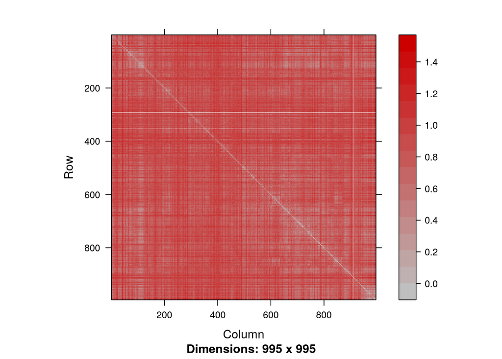

```r
# the distance matrix itself
image( Matrix( chr1.pcdist ) )
```

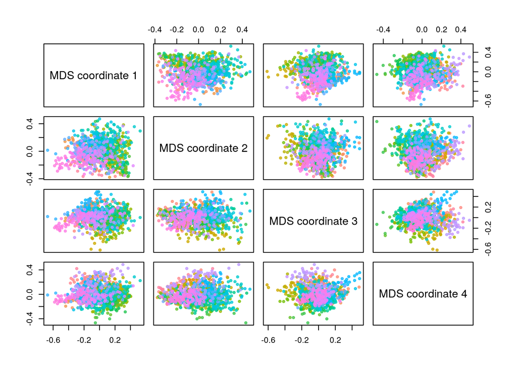

```r
# the MDS results
win.regions <- region(win.fn.snp)()
win.mids <- (win.regions$start+win.regions$end)/2
chrom.cols <- rainbow_hcl(128, c=90, end=.9*360)[as.numeric(cut(win.mids,128))]
pairs( mds.coords, pch=20, col=adjustcolor(chrom.cols,0.75) )
```

Now let’s extract the extreme windows in the MDS plot:

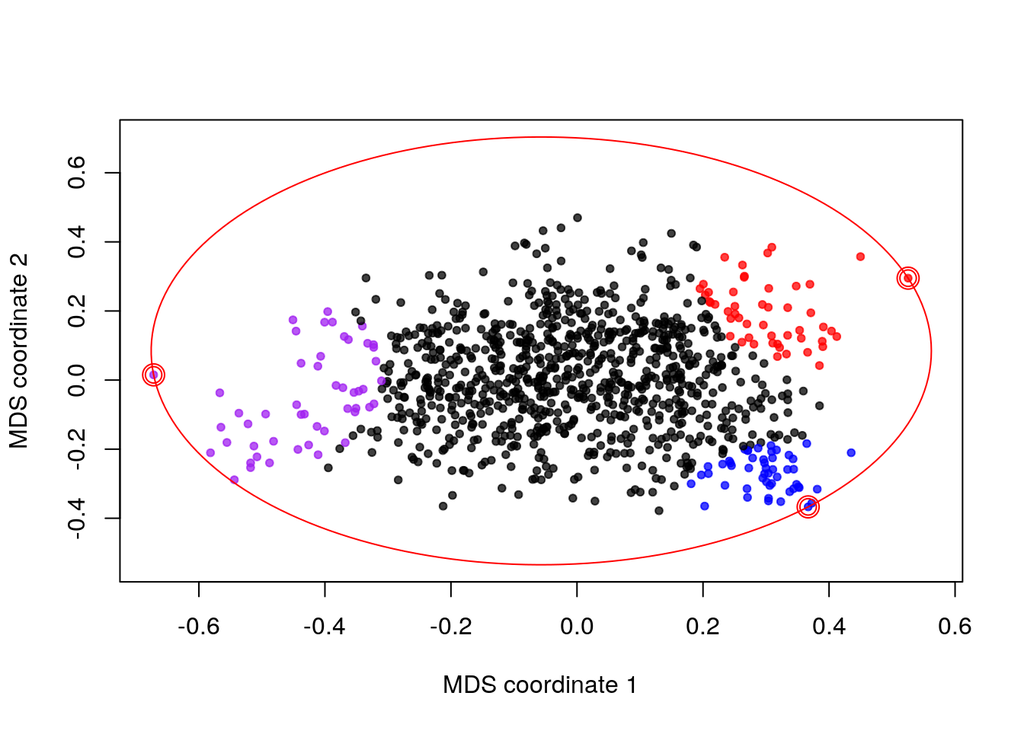

```r
mincirc <- enclosing_circle( mds.coords[,1:2] )
mds.corners <- corners( mds.coords[,1:2], prop=.05 )
corner.cols <- c("red","blue","purple")
ccols <- rep("black",nrow(mds.coords))
for (k in 1:ncol(mds.corners)) {
    ccols[ mds.corners[,k] ] <- corner.cols[k]
}
plot( mds.coords[,1:2], pch=20, col=adjustcolor(ccols,0.75),
        xlab="MDS coordinate 1", ylab="MDS coordinate 2",
        xlim=mincirc$ctr[1]+c(-1,1)*mincirc$rad,
        ylim=mincirc$ctr[2]+c(-1,1)*mincirc$rad )
plot_circle( mincirc, col='red' )
points( mincirc$three, col='red', cex=2 )
points( mds.coords[mincirc$index,], col='red', cex=1.5 )
```

Here is where these lie along the chromosomes:

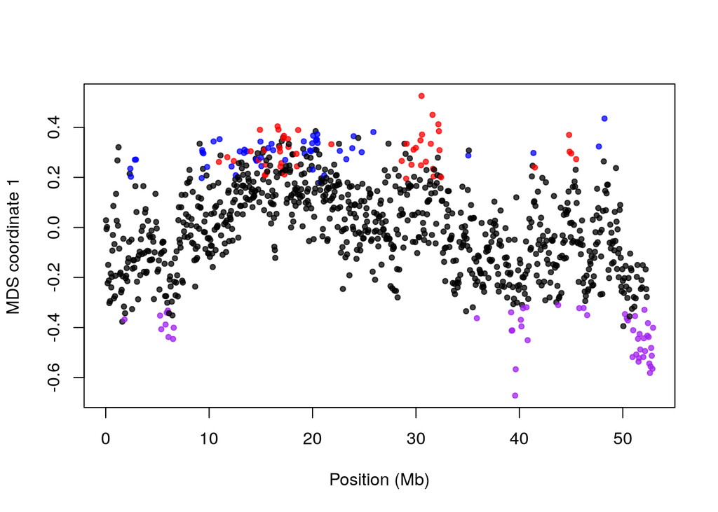

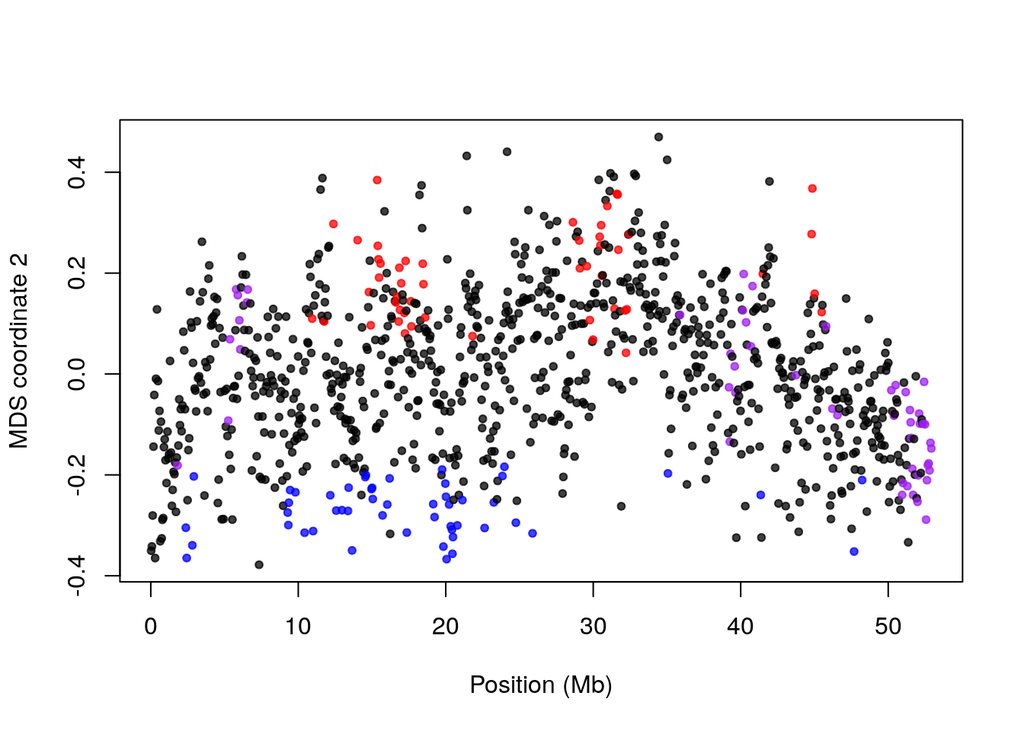

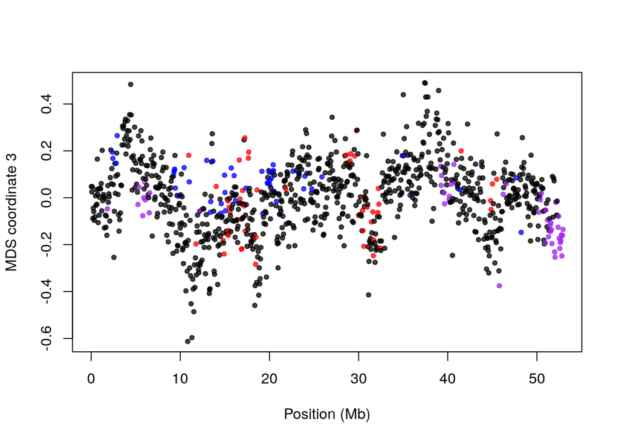

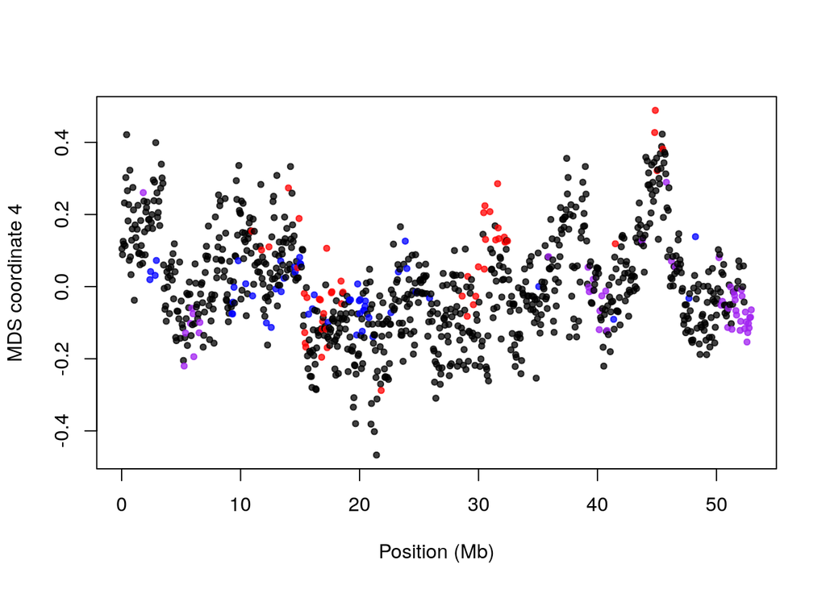

```r
for (k in 1:ncol(mds.coords)) {
    plot( win.mids/1e6, mds.coords[,k], pch=20,
            xlab="Position (Mb)", ylab=paste("MDS coordinate",k),
            col=adjustcolor(ccols,0.75) )
}
```

And, here are the PCA plots corresponding to these corners:

```r
corner.winfn <- function (n) { win.fn.snp( mds.corners[,n] ) }
corner.pcs <- eigen_windows( data=corner.winfn,
                    k=2, do.windows=1:ncol(mds.corners) )
```

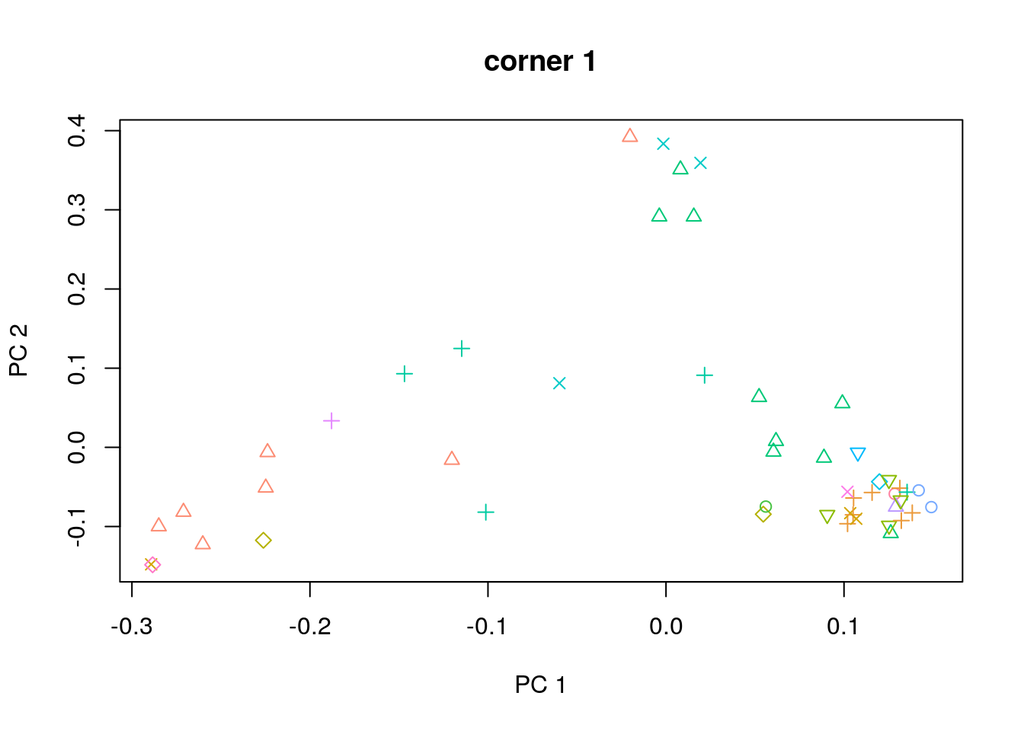

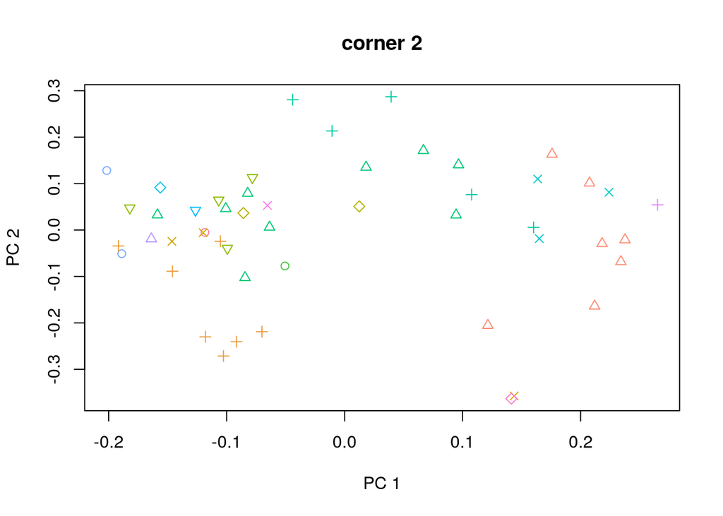

```r
countries <- samples$Country.of.Origin[match(do.indivs,samples$ID)]
country.names <- unique(countries)
country.cols <- rainbow_hcl( length(country.names), c=90 )
country.pch <- rep(1:6,length.out=length(country.names))
for (k in 1:ncol(corner.pcs$vectors)) {
    xy <- matrix( corner.pcs$vectors[,k], nrow=nrow(corner.pcs$vectors)/nrow(corner.pcs$values) )
    plot(xy, xlab="PC 1", ylab="PC 2", main=paste("corner",k),
            col=country.cols[match(countries,country.names)],
            pch=country.pch[match(countries,country.names)]  )
}
```

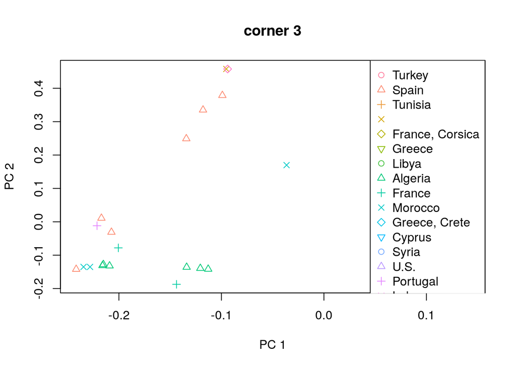

```r
legend('topright', col=country.cols, pch=country.pch, legend=country.names)
```